# starbility: plot coefficient stability under combinations of controls (advanced usage)

This vignette is designed for users who would like greater control over the default functions in `starbility`. If you have not yet done so, please first review the [main vignette](https://htmlpreview.github.io/?https://github.com/AakaashRao/starbility/blob/master/doc/starbility.html).

This vignette will cover four topics:

1. An overview of the `starbility` pipeline
2. Estimating models that are not automatically supported in `starbility`. (Currently, the only function automatically supported is `felm`)
3. Manual `ggplot2` plotting
4. Combining multiple models in a single plot

As in the main vignette, we will use the `diamonds` dataset included in ``ggplot2`.

```r
library(tidyverse)
library(starbility)
library(lfe)
data("diamonds")
set.seed(43)
indices = sample(1:nrow(diamonds), replace=F, size=round(nrow(diamonds)/20))
diamonds = diamonds[indices,]
```

## Overview of `starbility` pipeline

`starbility` proceeds in six discrete steps, corresponding to six discrete functions: `create_grid`, `create_felm_formulas`, `create_model_estimates`, `create_plot_dfs`, `draw_panels`, and `combine_plots`. `stability_plot` wraps all of these steps for convenience, but we can also access each function individually. Alternatively, we can use the `run_to` argument in `stability_plot` to end execution before a given step and the `run_from` argument to begin execution at a given step. The typical use case is to skip a step and implement it ourselves if we desire more flexibility or an option not yet automatically implemented.

### Step 1: control grid

The first step is to create a data frame with the structure of each model to be estimated. Each column corresponds to a variable, each row corresponds to a model, and each cell takes value 1 if that variable is included in the model and value 0 otherwise. I will specify `run_to=2` to instruct `stability_plot` to run only Step 1.

```r
diamonds$high_clarity = diamonds$clarity %in% c('VS1','VVS2','VVS1','IF')

base_controls = c(
  'Diamond dimensions' = 'x + y + z'
)

perm_controls = c(
  'Depth' = 'depth',
  'Table width' = 'table'
)

perm_fe_controls = c(
  'Cut FE' = 'cut',
  'Color FE' = 'color'
)
nonperm_fe_controls = c(
  'Clarity FE (granular)' = 'clarity',
  'Clarity FE (binary)' = 'high_clarity'
)

grid1 = stability_plot(data = diamonds,
                      lhs = 'price',
                      rhs = 'carat',
                      perm = perm_controls,
                      base = base_controls,
                      perm_fe = perm_fe_controls,
                      nonperm_fe = nonperm_fe_controls,
                      run_to=2)

knitr::kable(grid1 %>% head(10))
```

| Diamond dimensions | Depth | Table width | Cut FE | Color FE | np_fe |
| --- | --- | --- | --- | --- | --- |
| 1 | 0 | 0 | 0 | 0 |  |
| 1 | 1 | 0 | 0 | 0 |  |
| 1 | 0 | 1 | 0 | 0 |  |
| 1 | 1 | 1 | 0 | 0 |  |
| 1 | 0 | 0 | 1 | 0 |  |
| 1 | 1 | 0 | 1 | 0 |  |
| 1 | 0 | 1 | 1 | 0 |  |
| 1 | 1 | 1 | 1 | 0 |  |
| 1 | 0 | 0 | 0 | 1 |  |
| 1 | 1 | 0 | 0 | 1 |  |

```r
knitr::kable(grid1 %>% tail(10))
```

|  | Diamond dimensions | Depth | Table width | Cut FE | Color FE | np_fe |
| --- | --- | --- | --- | --- | --- | --- |
| 39 | 1 | 0 | 1 | 1 | 0 | high_clarity |
| 40 | 1 | 1 | 1 | 1 | 0 | high_clarity |
| 41 | 1 | 0 | 0 | 0 | 1 | high_clarity |
| 42 | 1 | 1 | 0 | 0 | 1 | high_clarity |
| 43 | 1 | 0 | 1 | 0 | 1 | high_clarity |
| 44 | 1 | 1 | 1 | 0 | 1 | high_clarity |
| 45 | 1 | 0 | 0 | 1 | 1 | high_clarity |
| 46 | 1 | 1 | 0 | 1 | 1 | high_clarity |
| 47 | 1 | 0 | 1 | 1 | 1 | high_clarity |
| 48 | 1 | 1 | 1 | 1 | 1 | high_clarity |

### Step 2: add models to control grid

The second step is to use the output of Step 1 to build the formulas to be estimated. `starbility` contains built-in support for `felm`, but if we want to use other functions, such as `glm`, `plm`, `bife`, etc., we need to build the formulas ourselves. (An example follows later in this document). Let’s try running just this step using the `run_from` argument and plugging in our output from above:

```r
grid2 = stability_plot(grid = grid1,
                      data=diamonds,
                      lhs='price',
                      rhs='carat',
                      perm=perm_controls,
                      base=base_controls,
                      run_from=2,
                      run_to=3)


knitr::kable(grid2 %>% head(10))
```

| Diamond dimensions | Depth | Table width | np_fe | expr |
| --- | --- | --- | --- | --- |
| 1 | 0 | 0 | 0 | price~carat+x+y+z\|0\|0\|0 |
| 1 | 1 | 0 | 0 | price~carat+x+y+z+depth\|0\|0\|0 |
| 1 | 0 | 1 | 0 | price~carat+x+y+z+table\|0\|0\|0 |
| 1 | 1 | 1 | 0 | price~carat+x+y+z+depth+table\|0\|0\|0 |
| 1 | 0 | 0 | 0 | price~carat+x+y+z\|0\|0\|0 |
| 1 | 1 | 0 | 0 | price~carat+x+y+z+depth\|0\|0\|0 |
| 1 | 0 | 1 | 0 | price~carat+x+y+z+table\|0\|0\|0 |
| 1 | 1 | 1 | 0 | price~carat+x+y+z+depth+table\|0\|0\|0 |
| 1 | 0 | 0 | 0 | price~carat+x+y+z\|0\|0\|0 |
| 1 | 1 | 0 | 0 | price~carat+x+y+z+depth\|0\|0\|0 |

```r
knitr::kable(grid2 %>% tail(10))
```

|  | Diamond dimensions | Depth | Table width | np_fe | expr |
| --- | --- | --- | --- | --- | --- |
| 39 | 1 | 0 | 1 | high_clarity | price~carat+x+y+z+table\|high_clarity\|0\|0 |
| 40 | 1 | 1 | 1 | high_clarity | price~carat+x+y+z+depth+table\|high_clarity\|0\|0 |
| 41 | 1 | 0 | 0 | high_clarity | price~carat+x+y+z\|high_clarity\|0\|0 |
| 42 | 1 | 1 | 0 | high_clarity | price~carat+x+y+z+depth\|high_clarity\|0\|0 |
| 43 | 1 | 0 | 1 | high_clarity | price~carat+x+y+z+table\|high_clarity\|0\|0 |
| 44 | 1 | 1 | 1 | high_clarity | price~carat+x+y+z+depth+table\|high_clarity\|0\|0 |
| 45 | 1 | 0 | 0 | high_clarity | price~carat+x+y+z\|high_clarity\|0\|0 |
| 46 | 1 | 1 | 0 | high_clarity | price~carat+x+y+z+depth\|high_clarity\|0\|0 |
| 47 | 1 | 0 | 1 | high_clarity | price~carat+x+y+z+table\|high_clarity\|0\|0 |
| 48 | 1 | 1 | 1 | high_clarity | price~carat+x+y+z+depth+table\|high_clarity\|0\|0 |

### Step 3: estimate models

The third step is to estimate the formulas above we generated in Step 2:

```r
grid3 = stability_plot(grid = grid2,
                      data=diamonds,
                      lhs='price',
                      rhs='carat',
                      perm=perm_controls,
                      base=base_controls,
                      run_from=3,
                      run_to=4)

knitr::kable(grid3 %>% head(10))
```

| Diamond dimensions | Depth | Table width | np_fe | expr | coef | p | error_high | error_low |
| --- | --- | --- | --- | --- | --- | --- | --- | --- |
| 1 | 0 | 0 | 0 | price~carat+x+y+z\|0\|0\|0 | 10461.86 | p<0.01 | 11031.84 | 9891.876 |
| 1 | 1 | 0 | 0 | price~carat+x+y+z+depth\|0\|0\|0 | 10808.25 | p<0.01 | 11388.81 | 10227.683 |
| 1 | 0 | 1 | 0 | price~carat+x+y+z+table\|0\|0\|0 | 10423.42 | p<0.01 | 10992.00 | 9854.849 |
| 1 | 1 | 1 | 0 | price~carat+x+y+z+depth+table\|0\|0\|0 | 10851.31 | p<0.01 | 11428.58 | 10274.037 |
| 1 | 0 | 0 | 0 | price~carat+x+y+z\|0\|0\|0 | 10461.86 | p<0.01 | 11031.84 | 9891.876 |
| 1 | 1 | 0 | 0 | price~carat+x+y+z+depth\|0\|0\|0 | 10808.25 | p<0.01 | 11388.81 | 10227.683 |
| 1 | 0 | 1 | 0 | price~carat+x+y+z+table\|0\|0\|0 | 10423.42 | p<0.01 | 10992.00 | 9854.849 |
| 1 | 1 | 1 | 0 | price~carat+x+y+z+depth+table\|0\|0\|0 | 10851.31 | p<0.01 | 11428.58 | 10274.037 |
| 1 | 0 | 0 | 0 | price~carat+x+y+z\|0\|0\|0 | 10461.86 | p<0.01 | 11031.84 | 9891.876 |
| 1 | 1 | 0 | 0 | price~carat+x+y+z+depth\|0\|0\|0 | 10808.25 | p<0.01 | 11388.81 | 10227.683 |

```r
knitr::kable(grid3 %>% tail(10))
```

|  | Diamond dimensions | Depth | Table width | np_fe | expr | coef | p | error_high | error_low |
| --- | --- | --- | --- | --- | --- | --- | --- | --- | --- |
| 39 | 1 | 0 | 1 | high_clarity | price~carat+x+y+z+table\|high_clarity\|0\|0 | 10125.99 | p<0.01 | 10660.82 | 9591.163 |
| 40 | 1 | 1 | 1 | high_clarity | price~carat+x+y+z+depth+table\|high_clarity\|0\|0 | 10456.79 | p<0.01 | 11002.18 | 9911.405 |
| 41 | 1 | 0 | 0 | high_clarity | price~carat+x+y+z\|high_clarity\|0\|0 | 10155.28 | p<0.01 | 10691.08 | 9619.477 |
| 42 | 1 | 1 | 0 | high_clarity | price~carat+x+y+z+depth\|high_clarity\|0\|0 | 10415.45 | p<0.01 | 10962.96 | 9867.945 |
| 43 | 1 | 0 | 1 | high_clarity | price~carat+x+y+z+table\|high_clarity\|0\|0 | 10125.99 | p<0.01 | 10660.82 | 9591.163 |
| 44 | 1 | 1 | 1 | high_clarity | price~carat+x+y+z+depth+table\|high_clarity\|0\|0 | 10456.79 | p<0.01 | 11002.18 | 9911.405 |
| 45 | 1 | 0 | 0 | high_clarity | price~carat+x+y+z\|high_clarity\|0\|0 | 10155.28 | p<0.01 | 10691.08 | 9619.477 |
| 46 | 1 | 1 | 0 | high_clarity | price~carat+x+y+z+depth\|high_clarity\|0\|0 | 10415.45 | p<0.01 | 10962.96 | 9867.945 |
| 47 | 1 | 0 | 1 | high_clarity | price~carat+x+y+z+table\|high_clarity\|0\|0 | 10125.99 | p<0.01 | 10660.82 | 9591.163 |
| 48 | 1 | 1 | 1 | high_clarity | price~carat+x+y+z+depth+table\|high_clarity\|0\|0 | 10456.79 | p<0.01 | 11002.18 | 9911.405 |

Adjusting p-values, standard errors (e.g. robust, Conley), the width of confidence intervals, etc. is simple; an example is given in the main vignette. Using models other than `felm` is also simple once we have the data frame of formulas in place; an example follows later in this document.

### Step 4: create dataframes to plot

The fourth step is to create two data frames, one for the coefficient panel (top) and one for the control panel (bottom). These are converted to tidy format to allow for easy plotting.

```r
dfs = stability_plot(grid = grid3,
                      data=diamonds,
                      lhs='price',
                      rhs='carat',
                      perm=perm_controls,
                      base=base_controls,
                      run_from=4,
                      run_to=5)

coef_grid = dfs[[1]]
control_grid = dfs[[2]]

knitr::kable(coef_grid %>% head(10))
```

| Diamond dimensions | Depth | Table width | np_fe | expr | coef | p | error_high | error_low | model |
| --- | --- | --- | --- | --- | --- | --- | --- | --- | --- |
| 1 | 0 | 0 | 0 | price~carat+x+y+z\|0\|0\|0 | 10461.86 | p<0.01 | 11031.84 | 9891.876 | 1 |
| 1 | 1 | 0 | 0 | price~carat+x+y+z+depth\|0\|0\|0 | 10808.25 | p<0.01 | 11388.81 | 10227.683 | 2 |
| 1 | 0 | 1 | 0 | price~carat+x+y+z+table\|0\|0\|0 | 10423.42 | p<0.01 | 10992.00 | 9854.849 | 3 |
| 1 | 1 | 1 | 0 | price~carat+x+y+z+depth+table\|0\|0\|0 | 10851.31 | p<0.01 | 11428.58 | 10274.037 | 4 |
| 1 | 0 | 0 | 0 | price~carat+x+y+z\|0\|0\|0 | 10461.86 | p<0.01 | 11031.84 | 9891.876 | 5 |
| 1 | 1 | 0 | 0 | price~carat+x+y+z+depth\|0\|0\|0 | 10808.25 | p<0.01 | 11388.81 | 10227.683 | 6 |
| 1 | 0 | 1 | 0 | price~carat+x+y+z+table\|0\|0\|0 | 10423.42 | p<0.01 | 10992.00 | 9854.849 | 7 |
| 1 | 1 | 1 | 0 | price~carat+x+y+z+depth+table\|0\|0\|0 | 10851.31 | p<0.01 | 11428.58 | 10274.037 | 8 |
| 1 | 0 | 0 | 0 | price~carat+x+y+z\|0\|0\|0 | 10461.86 | p<0.01 | 11031.84 | 9891.876 | 9 |
| 1 | 1 | 0 | 0 | price~carat+x+y+z+depth\|0\|0\|0 | 10808.25 | p<0.01 | 11388.81 | 10227.683 | 10 |

```r
knitr::kable(coef_grid %>% tail(10))
```

|  | Diamond dimensions | Depth | Table width | np_fe | expr | coef | p | error_high | error_low | model |
| --- | --- | --- | --- | --- | --- | --- | --- | --- | --- | --- |
| 39 | 1 | 0 | 1 | high_clarity | price~carat+x+y+z+table\|high_clarity\|0\|0 | 10125.99 | p<0.01 | 10660.82 | 9591.163 | 39 |
| 40 | 1 | 1 | 1 | high_clarity | price~carat+x+y+z+depth+table\|high_clarity\|0\|0 | 10456.79 | p<0.01 | 11002.18 | 9911.405 | 40 |
| 41 | 1 | 0 | 0 | high_clarity | price~carat+x+y+z\|high_clarity\|0\|0 | 10155.28 | p<0.01 | 10691.08 | 9619.477 | 41 |
| 42 | 1 | 1 | 0 | high_clarity | price~carat+x+y+z+depth\|high_clarity\|0\|0 | 10415.45 | p<0.01 | 10962.96 | 9867.945 | 42 |
| 43 | 1 | 0 | 1 | high_clarity | price~carat+x+y+z+table\|high_clarity\|0\|0 | 10125.99 | p<0.01 | 10660.82 | 9591.163 | 43 |
| 44 | 1 | 1 | 1 | high_clarity | price~carat+x+y+z+depth+table\|high_clarity\|0\|0 | 10456.79 | p<0.01 | 11002.18 | 9911.405 | 44 |
| 45 | 1 | 0 | 0 | high_clarity | price~carat+x+y+z\|high_clarity\|0\|0 | 10155.28 | p<0.01 | 10691.08 | 9619.477 | 45 |
| 46 | 1 | 1 | 0 | high_clarity | price~carat+x+y+z+depth\|high_clarity\|0\|0 | 10415.45 | p<0.01 | 10962.96 | 9867.945 | 46 |
| 47 | 1 | 0 | 1 | high_clarity | price~carat+x+y+z+table\|high_clarity\|0\|0 | 10125.99 | p<0.01 | 10660.82 | 9591.163 | 47 |
| 48 | 1 | 1 | 1 | high_clarity | price~carat+x+y+z+depth+table\|high_clarity\|0\|0 | 10456.79 | p<0.01 | 11002.18 | 9911.405 | 48 |

```r
knitr::kable(control_grid %>% head(10))
```

| model | key | value | y |
| --- | --- | --- | --- |
| 1 | Diamond dimensions | 1 | -1 |
| 2 | Diamond dimensions | 1 | -1 |
| 3 | Diamond dimensions | 1 | -1 |
| 4 | Diamond dimensions | 1 | -1 |
| 5 | Diamond dimensions | 1 | -1 |
| 6 | Diamond dimensions | 1 | -1 |
| 7 | Diamond dimensions | 1 | -1 |
| 8 | Diamond dimensions | 1 | -1 |
| 9 | Diamond dimensions | 1 | -1 |
| 10 | Diamond dimensions | 1 | -1 |

```r
knitr::kable(control_grid %>% tail(10))
```

|  | model | key | value | y |
| --- | --- | --- | --- | --- |
| 135 | 39 | Table width | 1 | -3 |
| 136 | 40 | Table width | 1 | -3 |
| 137 | 41 | Table width | 0 | -3 |
| 138 | 42 | Table width | 0 | -3 |
| 139 | 43 | Table width | 1 | -3 |
| 140 | 44 | Table width | 1 | -3 |
| 141 | 45 | Table width | 0 | -3 |
| 142 | 46 | Table width | 0 | -3 |
| 143 | 47 | Table width | 1 | -3 |
| 144 | 48 | Table width | 1 | -3 |

### Step 5: draw panels

The fifth step is to draw the two panels using `ggplot2`.

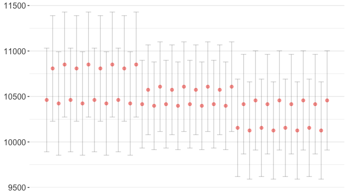

```r
panels = stability_plot(data = diamonds,
                      lhs='price',
                      rhs='carat',
                      coef_grid = coef_grid,
                      control_grid = control_grid,
                      run_from=5,
                      run_to=6)

panels[[1]]
```

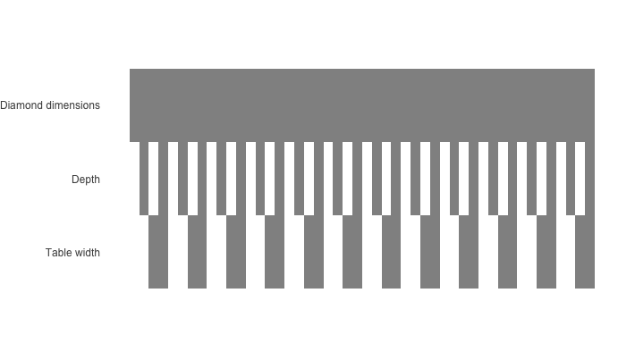

```r
panels[[2]]
```

### Step 6: combine panels

The final step is to combine the two panels:

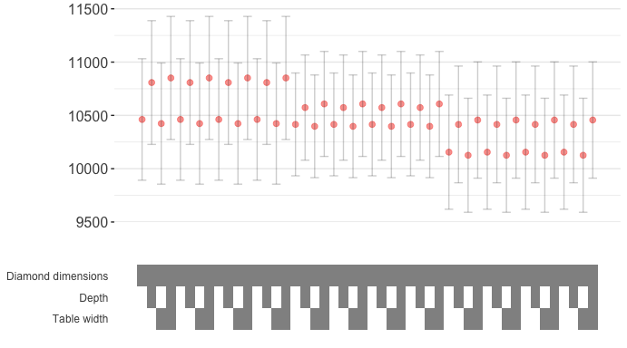

```r
stability_plot(data = diamonds,
               lhs='price',
               rhs='carat',
               coef_panel = panels[[1]],
               control_panel = panels[[2]],
               run_from = 6,
               run_to = 7)
```

We’ve recovered the original plot! Let’s now explore some use cases.

## Estimating custom functions

Let’s try implementing a logit model using `glm`, modeling the effect of carat on an indicator for whether the diamond is above median price. Since `glm` uses different syntax (no fixed effects!) we’ll need to build our formulas by hand in Step 2.

```r
diamonds$above_med_price = as.numeric(diamonds$price > median(diamonds$price))

base_controls = c(
  'Diamond dimensions' = 'x + y + z'
)

perm_controls = c(
  'Depth' = 'depth',
  'Table width' = 'table',
  'Clarity' = 'clarity'
)
lhs_var = 'above_med_price'
rhs_var = 'carat'

grid1 = stability_plot(data = diamonds,
                      lhs = lhs_var,
                      rhs = rhs_var,
                      perm = perm_controls,
                      base = base_controls,
                      fe_always = F,
               run_to=2)

# Create control part of formula
  base_perm = c(base_controls, perm_controls)
  grid1$expr = apply(grid1[,1:length(base_perm)], 1,
                     function(x) paste(base_perm[names(base_perm)[which(x==1)]], collapse='+'))

# Complete formula with LHS and RHS variables
  grid1$expr = paste(lhs_var, '~', rhs_var, '+', grid1$expr, sep='')

  knitr::kable(grid1 %>% head(10))
```

| Diamond dimensions | Depth | Table width | Clarity | np_fe | expr |
| --- | --- | --- | --- | --- | --- |
| 1 | 0 | 0 | 0 |  | above_med_price~carat+x + y + z |
| 1 | 1 | 0 | 0 |  | above_med_price~carat+x + y + z+depth |
| 1 | 0 | 1 | 0 |  | above_med_price~carat+x + y + z+table |
| 1 | 1 | 1 | 0 |  | above_med_price~carat+x + y + z+depth+table |
| 1 | 0 | 0 | 1 |  | above_med_price~carat+x + y + z+clarity |
| 1 | 1 | 0 | 1 |  | above_med_price~carat+x + y + z+depth+clarity |
| 1 | 0 | 1 | 1 |  | above_med_price~carat+x + y + z+table+clarity |
| 1 | 1 | 1 | 1 |  | above_med_price~carat+x + y + z+depth+table+clarity |

```r
  knitr::kable(grid1 %>% tail(10))
```

| Diamond dimensions | Depth | Table width | Clarity | np_fe | expr |
| --- | --- | --- | --- | --- | --- |
| 1 | 0 | 0 | 0 |  | above_med_price~carat+x + y + z |
| 1 | 1 | 0 | 0 |  | above_med_price~carat+x + y + z+depth |
| 1 | 0 | 1 | 0 |  | above_med_price~carat+x + y + z+table |
| 1 | 1 | 1 | 0 |  | above_med_price~carat+x + y + z+depth+table |
| 1 | 0 | 0 | 1 |  | above_med_price~carat+x + y + z+clarity |
| 1 | 1 | 0 | 1 |  | above_med_price~carat+x + y + z+depth+clarity |
| 1 | 0 | 1 | 1 |  | above_med_price~carat+x + y + z+table+clarity |
| 1 | 1 | 1 | 1 |  | above_med_price~carat+x + y + z+depth+table+clarity |

Our grid seems to be in order. We will also need to define a custom function for our logit model:

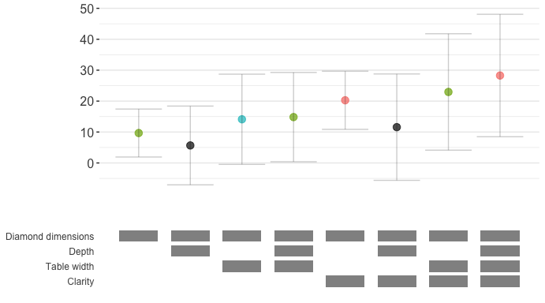

```r
starb_logit = function(spec, data, rhs, ...) {
  spec = as.formula(spec)
  model = glm(spec, data=data, family='binomial', weights=data$weight) %>%
    broom::tidy()
  row = which(model$term==rhs)
  coef = model[row, 'estimate'] %>% as.numeric()
  se   = model[row, 'std.error'] %>% as.numeric()
  p    = model[row, 'p.value'] %>% as.numeric()

  return(c(coef, p, coef+1.96*se, coef-1.96*se))
}

stability_plot(grid = grid1,
               data = diamonds,
               lhs = lhs_var,
               rhs = rhs_var,
               model = starb_logit,
               perm = perm_controls,
               base = base_controls,
               fe_always = F,
               run_from=3)
```

What if we want (average) marginal effects? Oh, and what if we want 99% CIs rather than 95% CIs? We can simply modify our estimation function accordingly. We’ll pass in a new `get_mfx` argument through the `...`:

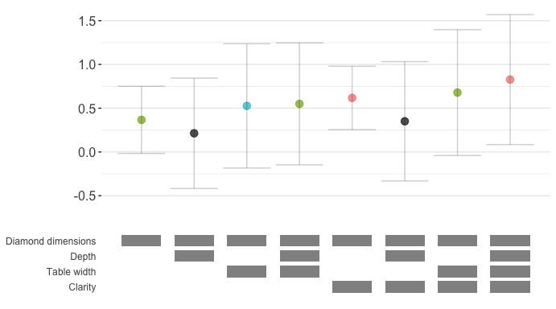

```r
library(margins)
starb_logit_enhanced = function(spec, data, rhs, ...) {
  # Unpack ...
  l = list(...)
  get_mfx = ifelse(is.null(l$get_mfx), F, T) # Set a default to F

  spec = as.formula(spec)
  if (get_mfx) {
    model = glm(spec, data=data, family='binomial', weights=data$weight) %>%
      margins() %>%
      summary
    row = which(model$factor==rhs)
    coef = model[row, 'AME'] %>% as.numeric()
    se   = model[row, 'SE'] %>% as.numeric()
    p    = model[row, 'p'] %>% as.numeric()
  } else {
    model = glm(spec, data=data, family='binomial', weights=data$weight) %>%
      broom::tidy()
    row = which(model$term==rhs)
    coef = model[row, 'estimate'] %>% as.numeric()
    se   = model[row, 'std.error'] %>% as.numeric()
    p    = model[row, 'p.value'] %>% as.numeric()
  }

  z = qnorm(0.995)
  return(c(coef, p, coef+z*se, coef-z*se))
}

stability_plot(grid = grid1,
               data = diamonds,
               lhs = lhs_var,
               rhs = rhs_var,
               model = starb_logit_enhanced,
               get_mfx = T,
               perm = perm_controls,
               base = base_controls,
               fe_always = F,
               run_from = 3)
```